# R Notebook

[output not shown]

| temperature |
| --- |
| 37 |
| 37.5-38 |
| 38.1-39 |
| 39.1-41 |

[output not shown]

# Introduction

Yet, what I have to consider is: - adjusting for multiple testing? - variance inflation factor (some are even calling this multiconlinearity but not sure of myself)? - and the last stage would be comparing the findings between all models - but also trying to understand the concept of confounders in health statistics

# Exploring the data

Age variable may not fit the model well. Therefore, I am calculating the percentages of age with comorbidities and see whether I can spot any age groups. I have 9 comorbidities and will take age and calculate the percentages. Obesity, diabetes type I and II, asthma, hypertension, heart_disease, lung condition, liver disease and kidney disease are the variables that would be calculated against age with the purpose of whether we can spot different age bands. Yet, analysis revealed different age bands based on observations made when observed towards different comorbidity groups. Yet, if I choose different age bands are these, then comparable? I thought it is worth keeping similar age bands across different models for the sake of comparability?I I will therefore, keep the age bands as 0-20, 21-30, 31 - 40, 41 -50, 51-60, 61-70, 71-80, 81-100, for the sake of comparability. But I have to check with more collegues on this.

# Obesity by age.

| age_rec | n | Percentage |
| --- | --- | --- |
| 2.0e+00 | 1 | 1.827e-04 |
| 3.0e+00 | 1 | 1.827e-04 |
| 4.0e+00 | 2 | 3.655e-04 |
| 5.0e+00 | 1 | 1.827e-04 |
| 7.0e+00 | 2 | 3.655e-04 |
| 1.0e+01 | 2 | 3.655e-04 |
| 1.2e+01 | 2 | 3.655e-04 |
| 1.3e+01 | 2 | 3.655e-04 |
| 1.5e+01 | 2 | 3.655e-04 |
| 1.6e+01 | 7 | 1.279e-03 |

[output cut: 72 more lines]

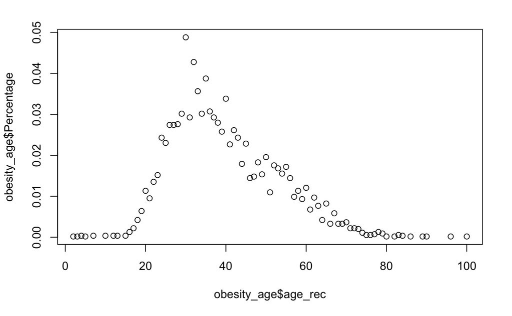

# Diabetes type I

Similar to obesity, the same groups can be spotted with the difference in groups 20-30 since there seem to be less respondents suffering of diabetes type 1, compared to 30 and 40 age group. 40 to 60 would form another group. Whereas 60 to 70 years of age and 80 to 100 would be treated as different groups.Thus, 0-20, 21 -30, 31-40, 41-60, 61-70, 70-80, 81-100.

| age_rec | n | Percentage |
| --- | --- | --- |
| 1.8e+01 | 2 | 4.246e-03 |
| 1.9e+01 | 3 | 6.369e-03 |
| 2.0e+01 | 3 | 6.369e-03 |
| 2.1e+01 | 1 | 2.123e-03 |
| 2.2e+01 | 5 | 1.062e-02 |
| 2.3e+01 | 2 | 4.246e-03 |
| 2.4e+01 | 4 | 8.493e-03 |
| 2.5e+01 | 4 | 8.493e-03 |
| 2.6e+01 | 3 | 6.369e-03 |
| 2.7e+01 | 5 | 1.062e-02 |

[output cut: 51 more lines]

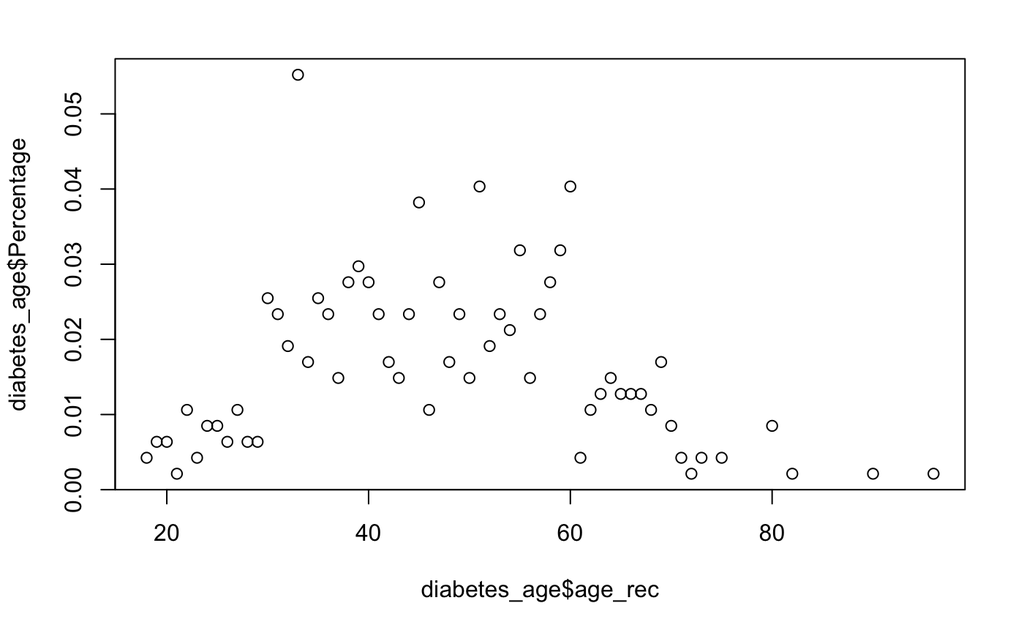

# Diabetes type II

As the plot suggests, following groups may be formed, 0-20, 21-30, 31-40, 41-60, 61-70, 71-80, 80-100.

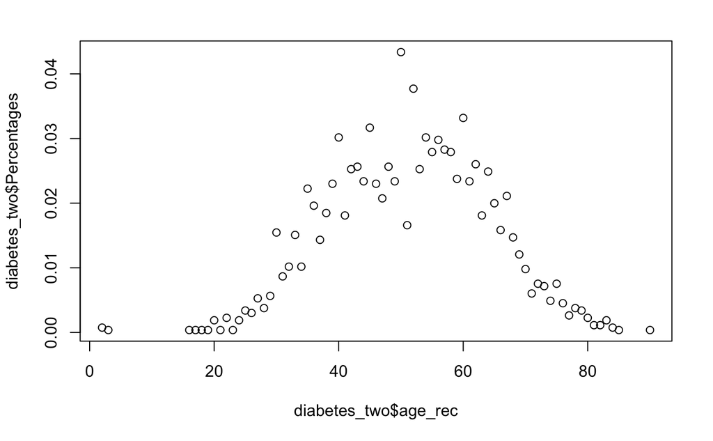

# Asthma

Asthma reveals the same patters with difference in 25 to 40 years of age, although debatable. Therefore the groups chosen for asthma modelling are 0-20, 21-30, 31-40, 41-50, 51-60, 61-70, 71-80, 81-100.

| age_rec | n | Percentages |
| --- | --- | --- |
| 2.0e+00 | 1 | 3.506e-04 |
| 3.0e+00 | 2 | 7.013e-04 |
| 4.0e+00 | 2 | 7.013e-04 |
| 5.0e+00 | 3 | 1.052e-03 |
| 6.0e+00 | 3 | 1.052e-03 |
| 7.0e+00 | 2 | 7.013e-04 |
| 8.0e+00 | 1 | 3.506e-04 |
| 9.0e+00 | 1 | 3.506e-04 |
| 1.0e+01 | 3 | 1.052e-03 |
| 1.1e+01 | 3 | 1.052e-03 |

[output cut: 72 more lines]

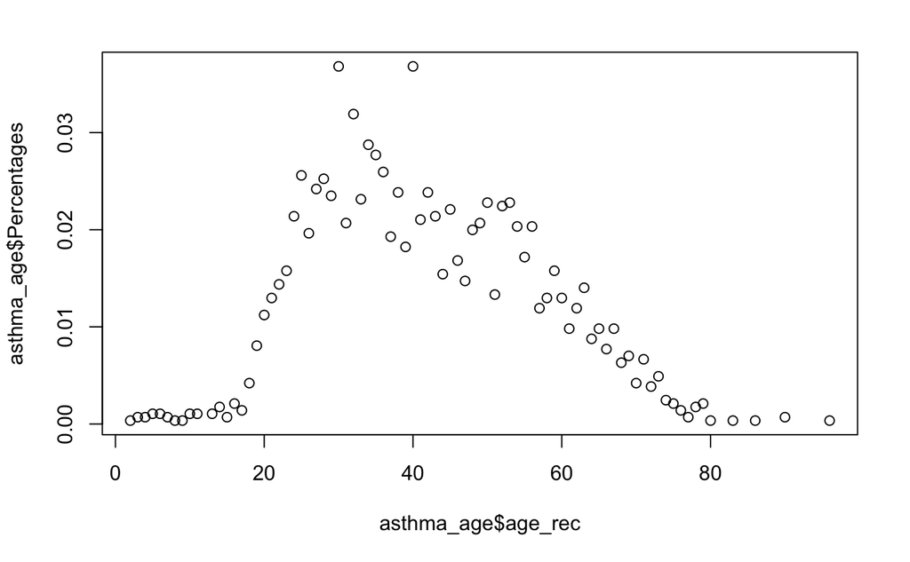

# Hypertension

Hypertension and age shows similiarities with previous plots. Therefore, the age_bands are 0-20, 21-30, 31-40, 41-50, 51-60, 61-70, 71-80, 81-100.

| age_rec | n | Percentages |
| --- | --- | --- |
| 0.0e+00 | 1 | 1.425e-04 |
| 2.0e+00 | 1 | 1.425e-04 |
| 3.0e+00 | 1 | 1.425e-04 |
| 4.0e+00 | 2 | 2.850e-04 |
| 5.0e+00 | 1 | 1.425e-04 |
| 6.0e+00 | 1 | 1.425e-04 |
| 1.2e+01 | 1 | 1.425e-04 |
| 1.5e+01 | 1 | 1.425e-04 |
| 1.6e+01 | 3 | 4.275e-04 |
| 1.7e+01 | 2 | 2.850e-04 |

[output cut: 72 more lines]

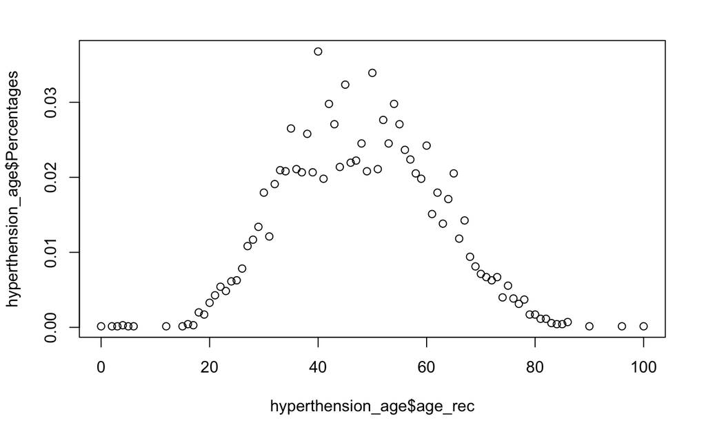

# Heart disease

Heart disease by age. The plot reveals different groups - 0-20, 21-30, 31-40, 41-50, 51-70, 71-80, 80-100.

| age_rec | n | Percentages |
| --- | --- | --- |
| 1.7e+01 | 1 | 1.473e-03 |
| 1.8e+01 | 2 | 2.946e-03 |
| 1.9e+01 | 2 | 2.946e-03 |
| 2.0e+01 | 4 | 5.891e-03 |
| 2.1e+01 | 2 | 2.946e-03 |
| 2.2e+01 | 7 | 1.031e-02 |
| 2.3e+01 | 5 | 7.364e-03 |
| 2.4e+01 | 4 | 5.891e-03 |
| 2.5e+01 | 6 | 8.837e-03 |
| 2.6e+01 | 3 | 4.418e-03 |

[output cut: 59 more lines]

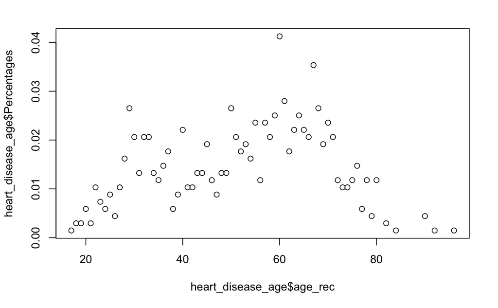

# Lung condition

Lung condidition by age.Groups emerging such as 0-20, 21-30, 31-40, 41-60, 61-70, 71-80, 80-100.

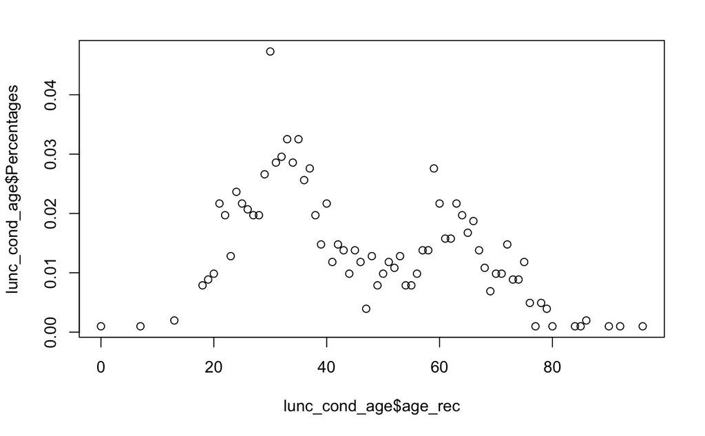

# Liver disease

Liver disease ha hig variation within the groups of 30 all the way to 40, the same as for the 40 to 50, yet not as in the 30 and 40 group. I would create groups from 0-20, 21-30, 31-40, 41-50, 51-60, 61-80. 80-100.

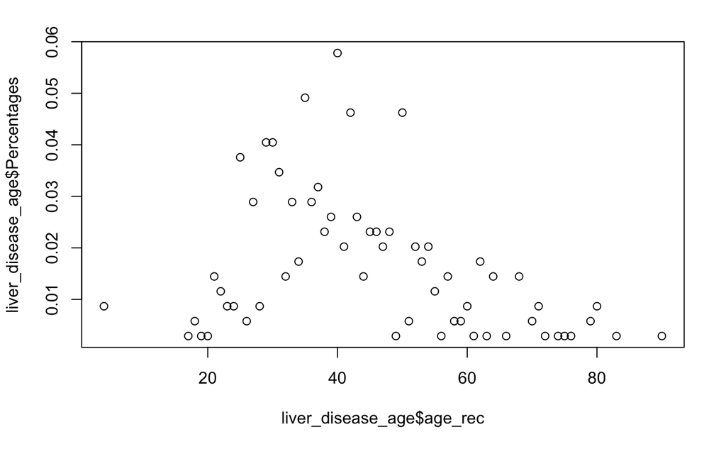

# Kidney disease

Kindney disease is suggesting more or less the same grouping. From 0-20, 21-30, 31-40, 41-60, 61-80, 80-100.

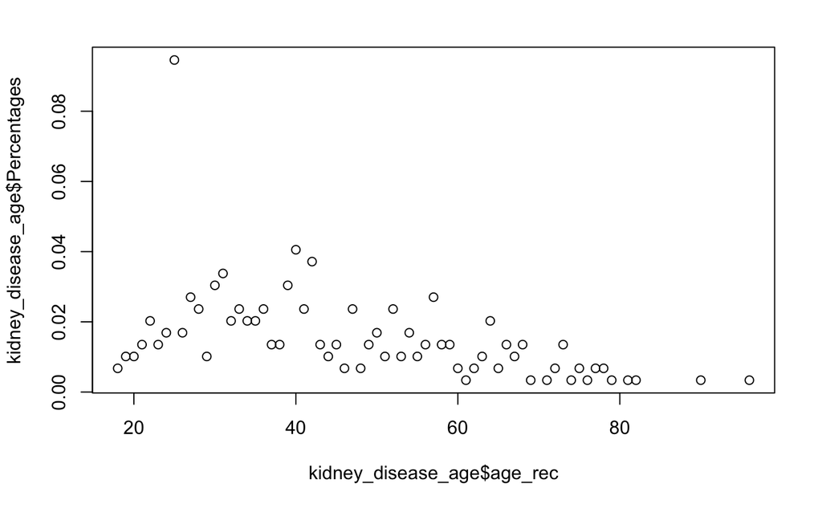

# Conclusion

However, if I have different age bands for different models, are these, then comparable? Is it worth keeping similar age bands across different models for the sake of comparability? I will therefore, keep the age bands as 0-20, 21-30, 31 - 40, 41 -50, 51-60, 61-70, 71-80, 81-100, for the sake of comparability.

# Gender

| Gender | n | percent |
| --- | --- | --- |
| Female | 26574 | 4.379e-01 |
| Male | 33952 | 5.594e-01 |
| Other | 163 | 2.686e-03 |

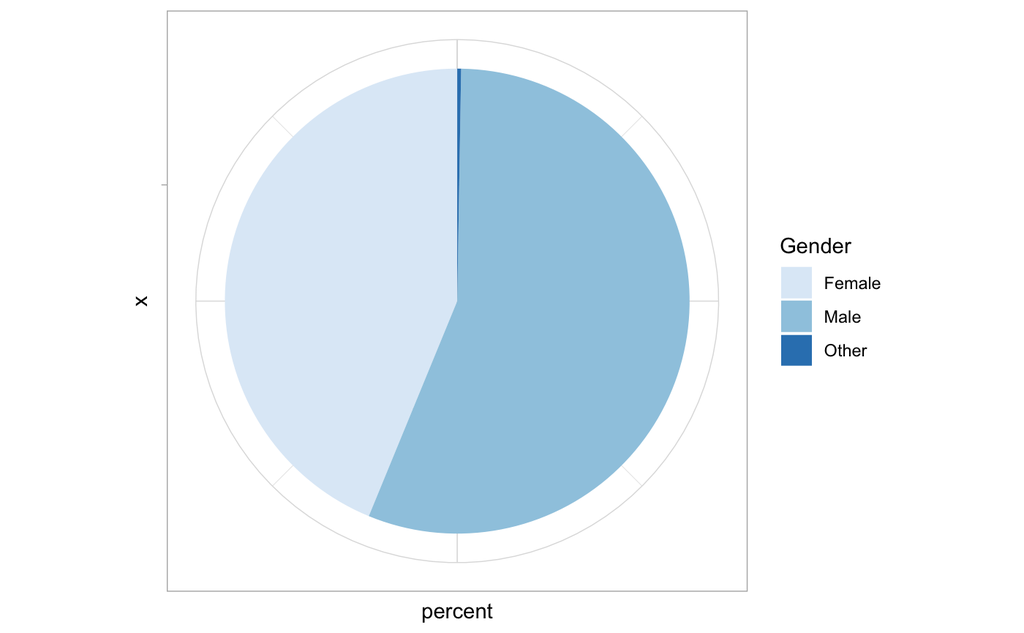

# Covid tested positive, negative, showing symptoms

I have recorded showing symptoms on its own category since a lot of respondents have not been tested but declare they show symptoms. I am keeping this three categories as they are since I am not attempting any predictive modeling but rather looking to differences and similarities symptoms of Covid in different comorbidity groups.

Table bellow is showing there are 8748 respondents showing symptoms but not tested, 713 tested positive and 51.351 are negative.

| covid_tested | n |
| --- | --- |
| negative | 51351 |
| positive | 713 |
| showing symptoms | 8748 |